# Risk Factor Analysis

## Outcome Variable

**Outcome Variable:** stunted

## Predictor Variables

**Intervention Variable:** hdlvry

**Adjustment Set:**

unadjusted

## Stratifying Variables

The analysis was stratified on these variable(s):

- agecat
- studyid
- country

## Data Summary

| agecat | studyid | country | hdlvry | stunted | n_cell | n |
| --- | --- | --- | --- | --- | --- | --- |
| Birth | CMC-V-BCS-2002 | INDIA | 0 | 0 | 75 | 92 |
| Birth | CMC-V-BCS-2002 | INDIA | 0 | 1 | 17 | 92 |
| Birth | CMC-V-BCS-2002 | INDIA | 1 | 0 | 0 | 92 |
| Birth | CMC-V-BCS-2002 | INDIA | 1 | 1 | 0 | 92 |
| Birth | COHORTS | INDIA | 0 | 0 | 2613 | 4694 |
| Birth | COHORTS | INDIA | 0 | 1 | 325 | 4694 |
| Birth | COHORTS | INDIA | 1 | 0 | 1534 | 4694 |
| Birth | COHORTS | INDIA | 1 | 1 | 222 | 4694 |
| Birth | EE | PAKISTAN | 0 | 0 | 93 | 238 |
| Birth | EE | PAKISTAN | 0 | 1 | 68 | 238 |
| Birth | EE | PAKISTAN | 1 | 0 | 46 | 238 |
| Birth | EE | PAKISTAN | 1 | 1 | 31 | 238 |
| Birth | GMS-Nepal | NEPAL | 0 | 0 | 125 | 646 |
| Birth | GMS-Nepal | NEPAL | 0 | 1 | 32 | 646 |
| Birth | GMS-Nepal | NEPAL | 1 | 0 | 408 | 646 |
| Birth | GMS-Nepal | NEPAL | 1 | 1 | 81 | 646 |
| Birth | IRC | INDIA | 0 | 0 | 337 | 388 |
| Birth | IRC | INDIA | 0 | 1 | 44 | 388 |
| Birth | IRC | INDIA | 1 | 0 | 6 | 388 |
| Birth | IRC | INDIA | 1 | 1 | 1 | 388 |
| Birth | JiVitA-3 | BANGLADESH | 0 | 0 | 23 | 334 |
| Birth | JiVitA-3 | BANGLADESH | 0 | 1 | 7 | 334 |
| Birth | JiVitA-3 | BANGLADESH | 1 | 0 | 220 | 334 |
| Birth | JiVitA-3 | BANGLADESH | 1 | 1 | 84 | 334 |
| Birth | JiVitA-4 | BANGLADESH | 0 | 0 | 420 | 2808 |
| Birth | JiVitA-4 | BANGLADESH | 0 | 1 | 134 | 2808 |
| Birth | JiVitA-4 | BANGLADESH | 1 | 0 | 1535 | 2808 |
| Birth | JiVitA-4 | BANGLADESH | 1 | 1 | 719 | 2808 |
| Birth | NIH-Crypto | BANGLADESH | 0 | 0 | 495 | 732 |
| Birth | NIH-Crypto | BANGLADESH | 0 | 1 | 72 | 732 |

[output cut: 98 more lines]

The following strata were considered:

- agecat: 24 months, studyid: CMC-V-BCS-2002, country: INDIA
- agecat: 24 months, studyid: COHORTS, country: INDIA
- agecat: 24 months, studyid: EE, country: PAKISTAN
- agecat: 24 months, studyid: GMS-Nepal, country: NEPAL
- agecat: 24 months, studyid: IRC, country: INDIA
- agecat: 24 months, studyid: JiVitA-3, country: BANGLADESH
- agecat: 24 months, studyid: JiVitA-4, country: BANGLADESH
- agecat: 24 months, studyid: NIH-Crypto, country: BANGLADESH
- agecat: 24 months, studyid: PROVIDE, country: BANGLADESH
- agecat: 24 months, studyid: TanzaniaChild2, country: TANZANIA, UNITED REPUBLIC OF
- agecat: 6 months, studyid: CMC-V-BCS-2002, country: INDIA
- agecat: 6 months, studyid: COHORTS, country: INDIA
- agecat: 6 months, studyid: EE, country: PAKISTAN
- agecat: 6 months, studyid: GMS-Nepal, country: NEPAL
- agecat: 6 months, studyid: IRC, country: INDIA
- agecat: 6 months, studyid: JiVitA-3, country: BANGLADESH
- agecat: 6 months, studyid: JiVitA-4, country: BANGLADESH
- agecat: 6 months, studyid: NIH-Crypto, country: BANGLADESH
- agecat: 6 months, studyid: PROVIDE, country: BANGLADESH
- agecat: 6 months, studyid: SAS-CompFeed, country: INDIA
- agecat: 6 months, studyid: SAS-FoodSuppl, country: INDIA
- agecat: 6 months, studyid: TanzaniaChild2, country: TANZANIA, UNITED REPUBLIC OF
- agecat: Birth, studyid: CMC-V-BCS-2002, country: INDIA
- agecat: Birth, studyid: COHORTS, country: INDIA
- agecat: Birth, studyid: EE, country: PAKISTAN
- agecat: Birth, studyid: GMS-Nepal, country: NEPAL
- agecat: Birth, studyid: IRC, country: INDIA
- agecat: Birth, studyid: JiVitA-3, country: BANGLADESH
- agecat: Birth, studyid: JiVitA-4, country: BANGLADESH
- agecat: Birth, studyid: NIH-Crypto, country: BANGLADESH
- agecat: Birth, studyid: PROVIDE, country: BANGLADESH
- agecat: Birth, studyid: SAS-CompFeed, country: INDIA

### Dropped Strata

Some strata were dropped due to rare outcomes:

- agecat: Birth, studyid: CMC-V-BCS-2002, country: INDIA
- agecat: Birth, studyid: IRC, country: INDIA
- agecat: 6 months, studyid: CMC-V-BCS-2002, country: INDIA
- agecat: 6 months, studyid: IRC, country: INDIA
- agecat: 24 months, studyid: CMC-V-BCS-2002, country: INDIA
- agecat: 24 months, studyid: IRC, country: INDIA
- agecat: 24 months, studyid: TanzaniaChild2, country: TANZANIA, UNITED REPUBLIC OF

## Methods Detail

We’re interested in the causal parameters $E[Y_a]$ for all values of $a \in \mathcal{A}$. These parameters represent the mean outcome if, possibly contrary to fact, we intervened to set all units to have $A=a$. Under the randomization and positivity assumptions, these are identified by the statistical parameters $\psi_a=E_W[E_{Y|A,W}(Y|A=a,W)]$. In addition, we’re interested in the mean of $Y$, $E[Y]$ under no intervention (the observed mean). We will estimate these parameters by using SuperLearner to fit the relevant likelihood factors – $E_{Y|A,W}(Y|A=a,W)$ and $p(A=a|W)$, and then updating our likelihood fit using a joint TMLE.

For unadjusted analyses ($W=\{\}$), initial likelihoods were estimated using Lrnr_glm to estimate the simple $E(Y|A)$ and Lrnr_mean to estimate $p(A)$. For adjusted analyses, a small library containing Lrnr_glmnet, Lrnr_xgboost, and Lrnr_mean was used.

Having estimated these parameters, we will then use the delta method to estimate relative risks and attributable risks relative to a prespecified baseline level of $A$.

# Results Detail

## Results Plots

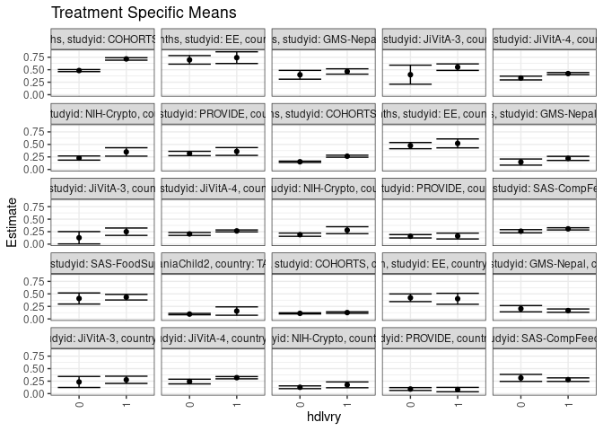

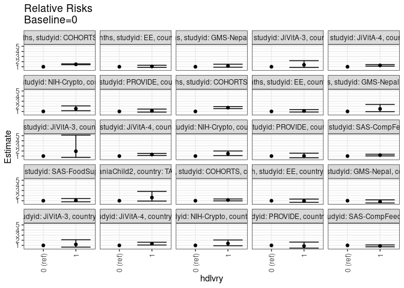

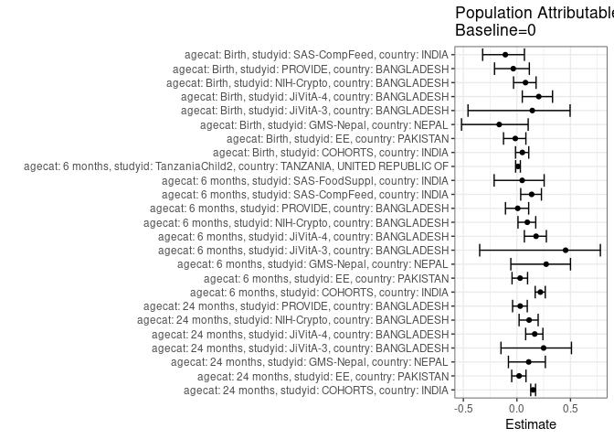

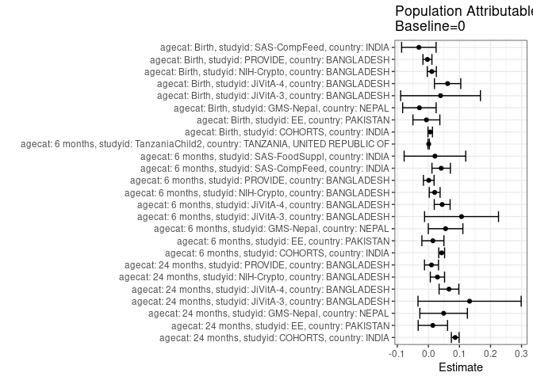

## Results Table

### Parameter: TSM

| agecat | studyid | country | intervention_level | baseline_level | estimate | ci_lower | ci_upper |
| --- | --- | --- | --- | --- | --- | --- | --- |
| Birth | COHORTS | INDIA | 0 | NA | 0.1106195 | 0.0992765 | 0.1219625 |
| Birth | COHORTS | INDIA | 1 | NA | 0.1264237 | 0.1108785 | 0.1419689 |
| Birth | EE | PAKISTAN | 0 | NA | 0.4223602 | 0.3459029 | 0.4988176 |
| Birth | EE | PAKISTAN | 1 | NA | 0.4025974 | 0.2928268 | 0.5123680 |
| Birth | GMS-Nepal | NEPAL | 0 | NA | 0.2038217 | 0.1407601 | 0.2668833 |
| Birth | GMS-Nepal | NEPAL | 1 | NA | 0.1656442 | 0.1326685 | 0.1986199 |
| Birth | JiVitA-3 | BANGLADESH | 0 | NA | 0.2333333 | 0.1228972 | 0.3437694 |
| Birth | JiVitA-3 | BANGLADESH | 1 | NA | 0.2763158 | 0.2043428 | 0.3482888 |
| Birth | JiVitA-4 | BANGLADESH | 0 | NA | 0.2418773 | 0.1946640 | 0.2890905 |
| Birth | JiVitA-4 | BANGLADESH | 1 | NA | 0.3189885 | 0.2962561 | 0.3417208 |
| Birth | NIH-Crypto | BANGLADESH | 0 | NA | 0.1269841 | 0.0995596 | 0.1544087 |
| Birth | NIH-Crypto | BANGLADESH | 1 | NA | 0.1757576 | 0.1176427 | 0.2338725 |
| Birth | PROVIDE | BANGLADESH | 0 | NA | 0.0920716 | 0.0633868 | 0.1207564 |
| Birth | PROVIDE | BANGLADESH | 1 | NA | 0.0810811 | 0.0370642 | 0.1250979 |
| Birth | SAS-CompFeed | INDIA | 0 | NA | 0.3145161 | 0.2442070 | 0.3848253 |
| Birth | SAS-CompFeed | INDIA | 1 | NA | 0.2799168 | 0.2445645 | 0.3152691 |
| 6 months | COHORTS | INDIA | 0 | NA | 0.1527586 | 0.1396637 | 0.1658535 |
| 6 months | COHORTS | INDIA | 1 | NA | 0.2645914 | 0.2442055 | 0.2849774 |
| 6 months | EE | PAKISTAN | 0 | NA | 0.4760000 | 0.4140083 | 0.5379917 |
| 6 months | EE | PAKISTAN | 1 | NA | 0.5206612 | 0.4315278 | 0.6097945 |
| 6 months | GMS-Nepal | NEPAL | 0 | NA | 0.1472868 | 0.0860732 | 0.2085005 |
| 6 months | GMS-Nepal | NEPAL | 1 | NA | 0.2205514 | 0.1798301 | 0.2612727 |
| 6 months | JiVitA-3 | BANGLADESH | 0 | NA | 0.1282051 | 0.0052540 | 0.2511562 |
| 6 months | JiVitA-3 | BANGLADESH | 1 | NA | 0.2491468 | 0.1752336 | 0.3230600 |
| 6 months | JiVitA-4 | BANGLADESH | 0 | NA | 0.2044403 | 0.1750893 | 0.2337914 |
| 6 months | JiVitA-4 | BANGLADESH | 1 | NA | 0.2651336 | 0.2461554 | 0.2841118 |
| 6 months | NIH-Crypto | BANGLADESH | 0 | NA | 0.1895307 | 0.1568715 | 0.2221899 |
| 6 months | NIH-Crypto | BANGLADESH | 1 | NA | 0.2795031 | 0.2101368 | 0.3488694 |
| 6 months | PROVIDE | BANGLADESH | 0 | NA | 0.1577778 | 0.1240694 | 0.1914862 |
| 6 months | PROVIDE | BANGLADESH | 1 | NA | 0.1623377 | 0.1040480 | 0.2206273 |
| 6 months | SAS-CompFeed | INDIA | 0 | NA | 0.2585034 | 0.2268011 | 0.2902057 |
| 6 months | SAS-CompFeed | INDIA | 1 | NA | 0.3061441 | 0.2844641 | 0.3278240 |
| 6 months | SAS-FoodSuppl | INDIA | 0 | NA | 0.4078947 | 0.2972611 | 0.5185283 |
| 6 months | SAS-FoodSuppl | INDIA | 1 | NA | 0.4342105 | 0.3784199 | 0.4900011 |
| 6 months | TanzaniaChild2 | TANZANIA, UNITED REPUBLIC OF | 0 | NA | 0.0963473 | 0.0829238 | 0.1097708 |
| 6 months | TanzaniaChild2 | TANZANIA, UNITED REPUBLIC OF | 1 | NA | 0.1562500 | 0.0724034 | 0.2400966 |
| 24 months | COHORTS | INDIA | 0 | NA | 0.4827586 | 0.4620297 | 0.5034875 |
| 24 months | COHORTS | INDIA | 1 | NA | 0.7150416 | 0.6907147 | 0.7393684 |
| 24 months | EE | PAKISTAN | 0 | NA | 0.6964286 | 0.6110164 | 0.7818408 |
| 24 months | EE | PAKISTAN | 1 | NA | 0.7407407 | 0.6235041 | 0.8579774 |
| 24 months | GMS-Nepal | NEPAL | 0 | NA | 0.3983051 | 0.3098791 | 0.4867311 |
| 24 months | GMS-Nepal | NEPAL | 1 | NA | 0.4644970 | 0.4112692 | 0.5177249 |
| 24 months | JiVitA-3 | BANGLADESH | 0 | NA | 0.4000000 | 0.2095503 | 0.5904497 |
| 24 months | JiVitA-3 | BANGLADESH | 1 | NA | 0.5507812 | 0.4856834 | 0.6158791 |
| 24 months | JiVitA-4 | BANGLADESH | 0 | NA | 0.3330106 | 0.2956577 | 0.3703636 |
| 24 months | JiVitA-4 | BANGLADESH | 1 | NA | 0.4222746 | 0.4008258 | 0.4437233 |
| 24 months | NIH-Crypto | BANGLADESH | 0 | NA | 0.2276215 | 0.1860204 | 0.2692225 |
| 24 months | NIH-Crypto | BANGLADESH | 1 | NA | 0.3495935 | 0.2652421 | 0.4339449 |
| 24 months | PROVIDE | BANGLADESH | 0 | NA | 0.3187067 | 0.2747786 | 0.3626348 |
| 24 months | PROVIDE | BANGLADESH | 1 | NA | 0.3586207 | 0.2804912 | 0.4367502 |

### Parameter: E(Y)

| agecat | studyid | country | intervention_level | baseline_level | estimate | ci_lower | ci_upper |
| --- | --- | --- | --- | --- | --- | --- | --- |
| Birth | COHORTS | INDIA | NA | NA | 0.1165317 | 0.1073518 | 0.1257117 |
| Birth | EE | PAKISTAN | NA | NA | 0.4159664 | 0.3532152 | 0.4787176 |
| Birth | GMS-Nepal | NEPAL | NA | NA | 0.1749226 | 0.1456043 | 0.2042409 |
| Birth | JiVitA-3 | BANGLADESH | NA | NA | 0.2724551 | 0.2076543 | 0.3372559 |
| Birth | JiVitA-4 | BANGLADESH | NA | NA | 0.3037749 | 0.2834613 | 0.3240886 |
| Birth | NIH-Crypto | BANGLADESH | NA | NA | 0.1379781 | 0.1129774 | 0.1629789 |
| Birth | PROVIDE | BANGLADESH | NA | NA | 0.0890538 | 0.0649864 | 0.1131212 |
| Birth | SAS-CompFeed | INDIA | NA | NA | 0.2838710 | 0.2475589 | 0.3201830 |
| 6 months | COHORTS | INDIA | NA | NA | 0.1955735 | 0.1842315 | 0.2069155 |
| 6 months | EE | PAKISTAN | NA | NA | 0.4905660 | 0.4396283 | 0.5415038 |
| 6 months | GMS-Nepal | NEPAL | NA | NA | 0.2026515 | 0.1683319 | 0.2369711 |
| 6 months | JiVitA-3 | BANGLADESH | NA | NA | 0.2349398 | 0.1664503 | 0.3034292 |
| 6 months | JiVitA-4 | BANGLADESH | NA | NA | 0.2488856 | 0.2328153 | 0.2649558 |
| 6 months | NIH-Crypto | BANGLADESH | NA | NA | 0.2097902 | 0.1799252 | 0.2396552 |
| 6 months | PROVIDE | BANGLADESH | NA | NA | 0.1589404 | 0.1297581 | 0.1881227 |
| 6 months | SAS-CompFeed | INDIA | NA | NA | 0.2997250 | 0.2767096 | 0.3227405 |
| 6 months | SAS-FoodSuppl | INDIA | NA | NA | 0.4289474 | 0.3791199 | 0.4787748 |
| 6 months | TanzaniaChild2 | TANZANIA, UNITED REPUBLIC OF | NA | NA | 0.0973451 | 0.0840860 | 0.1106043 |
| 24 months | COHORTS | INDIA | NA | NA | 0.5691789 | 0.5529008 | 0.5854569 |
| 24 months | EE | PAKISTAN | NA | NA | 0.7108434 | 0.6416667 | 0.7800200 |
| 24 months | GMS-Nepal | NEPAL | NA | NA | 0.4473684 | 0.4016814 | 0.4930554 |
| 24 months | JiVitA-3 | BANGLADESH | NA | NA | 0.5326460 | 0.4663548 | 0.5989373 |
| 24 months | JiVitA-4 | BANGLADESH | NA | NA | 0.3992509 | 0.3804088 | 0.4180930 |
| 24 months | NIH-Crypto | BANGLADESH | NA | NA | 0.2568093 | 0.2190047 | 0.2946140 |
| 24 months | PROVIDE | BANGLADESH | NA | NA | 0.3287197 | 0.2903909 | 0.3670485 |

### Parameter: RR

| agecat | studyid | country | intervention_level | baseline_level | estimate | ci_lower | ci_upper |
| --- | --- | --- | --- | --- | --- | --- | --- |
| Birth | COHORTS | INDIA | 0 | 0 | 1.0000000 | 1.0000000 | 1.000000 |
| Birth | COHORTS | INDIA | 1 | 0 | 1.1428702 | 0.9737860 | 1.341313 |
| Birth | EE | PAKISTAN | 0 | 0 | 1.0000000 | 1.0000000 | 1.000000 |
| Birth | EE | PAKISTAN | 1 | 0 | 0.9532086 | 0.6871520 | 1.322279 |
| Birth | GMS-Nepal | NEPAL | 0 | 0 | 1.0000000 | 1.0000000 | 1.000000 |
| Birth | GMS-Nepal | NEPAL | 1 | 0 | 0.8126917 | 0.5625292 | 1.174104 |
| Birth | JiVitA-3 | BANGLADESH | 0 | 0 | 1.0000000 | 1.0000000 | 1.000000 |
| Birth | JiVitA-3 | BANGLADESH | 1 | 0 | 1.1842105 | 0.6662901 | 2.104721 |
| Birth | JiVitA-4 | BANGLADESH | 0 | 0 | 1.0000000 | 1.0000000 | 1.000000 |
| Birth | JiVitA-4 | BANGLADESH | 1 | 0 | 1.3188031 | 1.0697808 | 1.625792 |
| Birth | NIH-Crypto | BANGLADESH | 0 | 0 | 1.0000000 | 1.0000000 | 1.000000 |
| Birth | NIH-Crypto | BANGLADESH | 1 | 0 | 1.3840909 | 0.9324945 | 2.054390 |
| Birth | PROVIDE | BANGLADESH | 0 | 0 | 1.0000000 | 1.0000000 | 1.000000 |
| Birth | PROVIDE | BANGLADESH | 1 | 0 | 0.8806306 | 0.4709344 | 1.646748 |
| Birth | SAS-CompFeed | INDIA | 0 | 0 | 1.0000000 | 1.0000000 | 1.000000 |
| Birth | SAS-CompFeed | INDIA | 1 | 0 | 0.8899917 | 0.7245584 | 1.093197 |
| 6 months | COHORTS | INDIA | 0 | 0 | 1.0000000 | 1.0000000 | 1.000000 |
| 6 months | COHORTS | INDIA | 1 | 0 | 1.7320884 | 1.5435253 | 1.943687 |
| 6 months | EE | PAKISTAN | 0 | 0 | 1.0000000 | 1.0000000 | 1.000000 |
| 6 months | EE | PAKISTAN | 1 | 0 | 1.0938260 | 0.8821278 | 1.356329 |
| 6 months | GMS-Nepal | NEPAL | 0 | 0 | 1.0000000 | 1.0000000 | 1.000000 |
| 6 months | GMS-Nepal | NEPAL | 1 | 0 | 1.4974278 | 0.9502539 | 2.359675 |
| 6 months | JiVitA-3 | BANGLADESH | 0 | 0 | 1.0000000 | 1.0000000 | 1.000000 |
| 6 months | JiVitA-3 | BANGLADESH | 1 | 0 | 1.9433447 | 0.7402346 | 5.101881 |
| 6 months | JiVitA-4 | BANGLADESH | 0 | 0 | 1.0000000 | 1.0000000 | 1.000000 |
| 6 months | JiVitA-4 | BANGLADESH | 1 | 0 | 1.2968751 | 1.1054772 | 1.521411 |
| 6 months | NIH-Crypto | BANGLADESH | 0 | 0 | 1.0000000 | 1.0000000 | 1.000000 |
| 6 months | NIH-Crypto | BANGLADESH | 1 | 0 | 1.4747116 | 1.0901648 | 1.994904 |
| 6 months | PROVIDE | BANGLADESH | 0 | 0 | 1.0000000 | 1.0000000 | 1.000000 |
| 6 months | PROVIDE | BANGLADESH | 1 | 0 | 1.0289007 | 0.6775131 | 1.562533 |
| 6 months | SAS-CompFeed | INDIA | 0 | 0 | 1.0000000 | 1.0000000 | 1.000000 |
| 6 months | SAS-CompFeed | INDIA | 1 | 0 | 1.1842942 | 1.0376684 | 1.351639 |
| 6 months | SAS-FoodSuppl | INDIA | 0 | 0 | 1.0000000 | 1.0000000 | 1.000000 |
| 6 months | SAS-FoodSuppl | INDIA | 1 | 0 | 1.0645161 | 0.7885142 | 1.437126 |
| 6 months | TanzaniaChild2 | TANZANIA, UNITED REPUBLIC OF | 0 | 0 | 1.0000000 | 1.0000000 | 1.000000 |
| 6 months | TanzaniaChild2 | TANZANIA, UNITED REPUBLIC OF | 1 | 0 | 1.6217376 | 0.9315439 | 2.823306 |
| 24 months | COHORTS | INDIA | 0 | 0 | 1.0000000 | 1.0000000 | 1.000000 |
| 24 months | COHORTS | INDIA | 1 | 0 | 1.4811575 | 1.4021978 | 1.564564 |
| 24 months | EE | PAKISTAN | 0 | 0 | 1.0000000 | 1.0000000 | 1.000000 |
| 24 months | EE | PAKISTAN | 1 | 0 | 1.0636277 | 0.8706277 | 1.299412 |
| 24 months | GMS-Nepal | NEPAL | 0 | 0 | 1.0000000 | 1.0000000 | 1.000000 |
| 24 months | GMS-Nepal | NEPAL | 1 | 0 | 1.1661841 | 0.9083742 | 1.497164 |
| 24 months | JiVitA-3 | BANGLADESH | 0 | 0 | 1.0000000 | 1.0000000 | 1.000000 |
| 24 months | JiVitA-3 | BANGLADESH | 1 | 0 | 1.3769531 | 0.8651229 | 2.191596 |
| 24 months | JiVitA-4 | BANGLADESH | 0 | 0 | 1.0000000 | 1.0000000 | 1.000000 |
| 24 months | JiVitA-4 | BANGLADESH | 1 | 0 | 1.2680512 | 1.1221126 | 1.432970 |
| 24 months | NIH-Crypto | BANGLADESH | 0 | 0 | 1.0000000 | 1.0000000 | 1.000000 |
| 24 months | NIH-Crypto | BANGLADESH | 1 | 0 | 1.5358546 | 1.1347332 | 2.078770 |
| 24 months | PROVIDE | BANGLADESH | 0 | 0 | 1.0000000 | 1.0000000 | 1.000000 |
| 24 months | PROVIDE | BANGLADESH | 1 | 0 | 1.1252374 | 0.8695261 | 1.456149 |

### Parameter: PAR

| agecat | studyid | country | intervention_level | baseline_level | estimate | ci_lower | ci_upper |
| --- | --- | --- | --- | --- | --- | --- | --- |
| Birth | COHORTS | INDIA | 0 | NA | 0.0059123 | -0.0012900 | 0.0131145 |
| Birth | EE | PAKISTAN | 0 | NA | -0.0063939 | -0.0496895 | 0.0369018 |
| Birth | GMS-Nepal | NEPAL | 0 | NA | -0.0288991 | -0.0827818 | 0.0249837 |
| Birth | JiVitA-3 | BANGLADESH | 0 | NA | 0.0391218 | -0.0892717 | 0.1675152 |
| Birth | JiVitA-4 | BANGLADESH | 0 | NA | 0.0618977 | 0.0194615 | 0.1043338 |
| Birth | NIH-Crypto | BANGLADESH | 0 | NA | 0.0109940 | -0.0035661 | 0.0255542 |
| Birth | PROVIDE | BANGLADESH | 0 | NA | -0.0030178 | -0.0174499 | 0.0114143 |
| Birth | SAS-CompFeed | INDIA | 0 | NA | -0.0306452 | -0.0861137 | 0.0248234 |
| 6 months | COHORTS | INDIA | 0 | NA | 0.0428149 | 0.0334094 | 0.0522204 |
| 6 months | EE | PAKISTAN | 0 | NA | 0.0145660 | -0.0209082 | 0.0500403 |
| 6 months | GMS-Nepal | NEPAL | 0 | NA | 0.0553647 | -0.0002588 | 0.1109882 |
| 6 months | JiVitA-3 | BANGLADESH | 0 | NA | 0.1067346 | -0.0122702 | 0.2257395 |
| 6 months | JiVitA-4 | BANGLADESH | 0 | NA | 0.0444453 | 0.0189581 | 0.0699324 |
| 6 months | NIH-Crypto | BANGLADESH | 0 | NA | 0.0202595 | 0.0027767 | 0.0377424 |
| 6 months | PROVIDE | BANGLADESH | 0 | NA | 0.0011626 | -0.0160062 | 0.0183314 |
| 6 months | SAS-CompFeed | INDIA | 0 | NA | 0.0412216 | 0.0115269 | 0.0709164 |
| 6 months | SAS-FoodSuppl | INDIA | 0 | NA | 0.0210526 | -0.0780768 | 0.1201821 |
| 6 months | TanzaniaChild2 | TANZANIA, UNITED REPUBLIC OF | 0 | NA | 0.0009979 | -0.0011525 | 0.0031482 |
| 24 months | COHORTS | INDIA | 0 | NA | 0.0864202 | 0.0739698 | 0.0988707 |
| 24 months | EE | PAKISTAN | 0 | NA | 0.0144148 | -0.0328765 | 0.0617061 |
| 24 months | GMS-Nepal | NEPAL | 0 | NA | 0.0490633 | -0.0274854 | 0.1256120 |
| 24 months | JiVitA-3 | BANGLADESH | 0 | NA | 0.1326460 | -0.0334276 | 0.2987197 |
| 24 months | JiVitA-4 | BANGLADESH | 0 | NA | 0.0662403 | 0.0344631 | 0.0980175 |
| 24 months | NIH-Crypto | BANGLADESH | 0 | NA | 0.0291879 | 0.0062351 | 0.0521406 |
| 24 months | PROVIDE | BANGLADESH | 0 | NA | 0.0100130 | -0.0125168 | 0.0325429 |

### Parameter: PAF

| agecat | studyid | country | intervention_level | baseline_level | estimate | ci_lower | ci_upper |
| --- | --- | --- | --- | --- | --- | --- | --- |
| Birth | COHORTS | INDIA | 0 | NA | 0.0507353 | -0.0130228 | 0.1104806 |
| Birth | EE | PAKISTAN | 0 | NA | -0.0153711 | -0.1249902 | 0.0835667 |
| Birth | GMS-Nepal | NEPAL | 0 | NA | -0.1652105 | -0.5169822 | 0.1049891 |
| Birth | JiVitA-3 | BANGLADESH | 0 | NA | 0.1435897 | -0.4564758 | 0.4964293 |
| Birth | JiVitA-4 | BANGLADESH | 0 | NA | 0.2037616 | 0.0501249 | 0.3325485 |
| Birth | NIH-Crypto | BANGLADESH | 0 | NA | 0.0796794 | -0.0313499 | 0.1787559 |
| Birth | PROVIDE | BANGLADESH | 0 | NA | -0.0338875 | -0.2090984 | 0.1159336 |
| Birth | SAS-CompFeed | INDIA | 0 | NA | -0.1079545 | -0.3199809 | 0.0700143 |
| 6 months | COHORTS | INDIA | 0 | NA | 0.2189197 | 0.1704333 | 0.2645722 |
| 6 months | EE | PAKISTAN | 0 | NA | 0.0296923 | -0.0454449 | 0.0994293 |
| 6 months | GMS-Nepal | NEPAL | 0 | NA | 0.2732015 | -0.0566987 | 0.5001072 |
| 6 months | JiVitA-3 | BANGLADESH | 0 | NA | 0.4543064 | -0.3476061 | 0.7790292 |
| 6 months | JiVitA-4 | BANGLADESH | 0 | NA | 0.1785770 | 0.0695188 | 0.2748530 |
| 6 months | NIH-Crypto | BANGLADESH | 0 | NA | 0.0965704 | 0.0099200 | 0.1756373 |
| 6 months | PROVIDE | BANGLADESH | 0 | NA | 0.0073148 | -0.1067961 | 0.1096609 |
| 6 months | SAS-CompFeed | INDIA | 0 | NA | 0.1375315 | 0.0354689 | 0.2287942 |
| 6 months | SAS-FoodSuppl | INDIA | 0 | NA | 0.0490798 | -0.2125598 | 0.2542641 |
| 6 months | TanzaniaChild2 | TANZANIA, UNITED REPUBLIC OF | 0 | NA | 0.0102507 | -0.0121270 | 0.0321337 |
| 24 months | COHORTS | INDIA | 0 | NA | 0.1518332 | 0.1291317 | 0.1739428 |
| 24 months | EE | PAKISTAN | 0 | NA | 0.0202785 | -0.0486804 | 0.0847027 |
| 24 months | GMS-Nepal | NEPAL | 0 | NA | 0.1096710 | -0.0791822 | 0.2654755 |
| 24 months | JiVitA-3 | BANGLADESH | 0 | NA | 0.2490323 | -0.1488662 | 0.5091225 |
| 24 months | JiVitA-4 | BANGLADESH | 0 | NA | 0.1659114 | 0.0817576 | 0.2423528 |
| 24 months | NIH-Crypto | BANGLADESH | 0 | NA | 0.1136557 | 0.0202907 | 0.1981232 |
| 24 months | PROVIDE | BANGLADESH | 0 | NA | 0.0304607 | -0.0405531 | 0.0966280 |